# **`CASE STUDY - 1` :: Healthcare Provider Fraudulent Detection**

[figure not shown]

**1. This notebook contains the extensive data analysis of { BENE + IP + OP + Frauds Providers Labels } performed on the publicly available dataset at [Kaggle](https://www.kaggle.com/datasets/rohitrox/healthcare-provider-fraud-detection-analysis) with the intent:**

- To gain better understanding of the dataset from different levels.
- To explore the dataset in order to uncover the potential hidden patterns.
- And, to find the answers of various WHYs.

**2. I have also added some new features with the intent to bring some more business aspects in the dataset. Also, performed their impact analysis on the potential frauds.**

**Kindly checkout the below Deck for better understanding the BUSINESS oriented insights about this problem:**

- [Deck : Detailed Explanation](https://docs.google.com/presentation/d/1Thuw_eZskafkl9W3xYuEVsjgTJKFeEkzEfAmczH96Uw/)

**Kindly checkout the below Doc for TECHNICAL Design description about this problem:**

- [Technical Document](https://docs.google.com/document/d/10z9xbn4dZWkforlAszCDaa1M0roAW-MOf2pjJHSnEXk/)

# **`Notebook Contents`**

> CASE STUDY - 1 :: Healthcare Provider Fraudulent Detection

> Notebook Contents

> > Downloading_Train_Data_Files

> > TRAIN set files

> > Importing_Libraries

> > Importing_Dataset

> > Exploring_Target_Labels_Data

> > > Adding the Admitted or Not Admitted indicator in IP and OP Dataset

> > > Merging the Datasets

> > > Merging the IP_OP Dataset with BENE Data

> > > Merging the IP_OP_BENE Dataset with PROVIDER level Tgt Labels Data

> > > Entire Dataset

> > > ASSUMPTION :: One provider may have been involved in more than one claim. So, does all the claims filed by a potentially fraud provider are all frauds?

> > > > Therefore, it is a big assumption to make that all the claims filed by a potentially fraud provider are fraudulent.

> > Feature Engineering + Impact Analysis

> > > Adding New Feature :: Is_Alive?

> > > Adding New Feature :: Claim_Duration

> > > Adding New Feature :: Admitted_Duration

> > > Adding New Feature :: Bene_Age

> > > Does InscClaimAmtReimbursed influences Potentially Fraud?

> > > Does IPAnnualReimbursementAmt influences Potentially Fraud?

> > > > Why do we have IP Annual Re-Imb Amount as 0 for Admitted Patients?

> > > Does OPAnnualReimbursementAmt influences Potentially Fraud?

> > > > Why do we have OP Annual Re-Imb Amount as 0 for Admitted Patients?

> > > Adding New Feature :: Total Number of false claims filed by a Provider

> > > Adding New Feature :: Total Number of claims or cases seen by Attending Physician

> > > Adding New Feature :: Total Number of claims or cases seen by Opearting Physician

> > > Adding New Feature :: Total Number of claims or cases seen by Other Physician

> > > Adding Combined Feature :: Att_Opr_Oth_Phy_Tot_Claims

> > > Adding 3 New Features :: Prv_Tot_Att_Phy, Prv_Tot_Opr_Phy and Prv_Tot_Oth_Phy

> > > Adding Combined Feature :: Prv_Tot_Att_Opr_Oth_Phys

> > > Adding New Feature :: Total Unique Claim Admit Codes used by a PROVIDER

> > > Adding New Feature :: Total Unique Number of Diagnosis Group Codes used by a PROVIDER

> > > Adding New Feature :: Total unique Date of Birth years of beneficiaries provided by a Provider

> > > Adding New Feature :: Sum of patients age treated by a Provider

> > > Adding New Feature :: Sum of Insc Claim Re-Imb Amount for a Provider

> > > Adding New Feature :: Total number of RKD Patients seen by a Provider

> > Exploratory Data Analysis

> > > Q1. Which are the Top-25 Providers with maximum number of fraudulent cases?

> > > Q2. Which are the Top-25 Providers with maximum number of non-fraudulent cases?

> > > Q3. Which are the Top-25 Attending Physicians with maximum number of fraudulent cases?

> > > Q4. Which are the Top-25 Attenting Physicians with maximum number of non-fraudulent cases?

> > > Q5. Which are the Top-25 Operating Physicians with maximum number of fraudulent cases?

> > > Q6. Which are the Top-25 Operating Physicians with maximum number of non-fraudulent cases?

> > > Q7. Which are the Top-25 Other Physicians with maximum number of fraudulent cases?

> > > Q8. Which are the Top-25 Other Physicians with maximum number of non-fraudulent cases?

> > > Q9. Which are the Top-25 ClmAdmitDiagnosisCode with maximum number of fraudulent cases?

> > > Q10. Which are the Top-25 ClmAdmitDiagnosisCode with maximum number of non-fraudulent cases?

> > > Q11. Which are the Top-25 DiagnosisGroupCode with maximum number of fraudulent cases?

> > > Q12. Which are the Top-25 DiagnosisGroupCode with maximum number of non-fraudulent cases?

> > > Q13. Does Age_groups have any relationship with maximum number of fraudulent cases?

> > > Q14. Does Age_groups have any relationship with maximum number of non-fraudulent cases?

> > > Q15. Which are the Top-25 States with maximum number of fraudulent cases?

> > > Q16. What are the Top-25 States with maximum number of non-fraudulent cases?

> > > Q17. Which are the Top-25 Country with maximum number of fraudulent cases?

> > > Q18. What are the Top-25 Country with maximum number of non-fraudulent cases?

> > > Q19. Does various Human Races have any relationship with maximum number of fraudulent cases?

> > > Q20. Does various Human Races have any relationship with maximum number of non-fraudulent cases?

## **Downloading_Train_Data_Files**

```python
## TRAIN set files

!gdown 12zSQN2FOxmuXFhz2xzPNussPisEfVP5w
!gdown 13XyBakfHiG-BNQPrYFXAHlsOcfICOTpx
!gdown 1dLxl4vkykPcm4Zj0abYR0Ohr7STQHg-1
!gdown 1rFER-7VuYb7GfCYeJrfxPidgK0lwqw3R
```

## **Importing_Libraries**

```python
import os
import sys
import math
import scipy as scipy
import numpy as np
import pandas as pd
import matplotlib.pyplot as plt
import seaborn as sns

%matplotlib inline
```

```python
pd.set_option('display.max_columns',80)
label_font_dict = {'family':'sans-serif','size':13.5,'color':'brown','style':'italic'}
title_font_dict = {'family':'sans-serif','size':16.5,'color':'Blue','style':'italic'}
```

## **Importing_Dataset**

```python
train_bene_df = pd.read_csv("Dataset/Train/Train_Beneficiarydata-1542865627584.csv")
train_ip_df = pd.read_csv("Dataset/Train/Train_Inpatientdata-1542865627584.csv")
train_op_df = pd.read_csv("Dataset/Train/Train_Outpatientdata-1542865627584.csv")
train_tgt_lbls_df = pd.read_csv("Dataset/Train/Train-1542865627584.csv")
```

## *Exploring_Target_Labels_Data*

```python
train_tgt_lbls_df.head()
```

|  | Provider | PotentialFraud |
| --- | --- | --- |
| 0 | PRV51001 | No |
| 1 | PRV51003 | Yes |
| 2 | PRV51004 | No |
| 3 | PRV51005 | Yes |
| 4 | PRV51007 | No |

- **Check the Fraud and Non-Fraud Counts**

```python
print("### The unique number of providers are {}. ###".format(train_tgt_lbls_df.shape[0]))
```

```
### The unique number of providers are 5410. ###
```

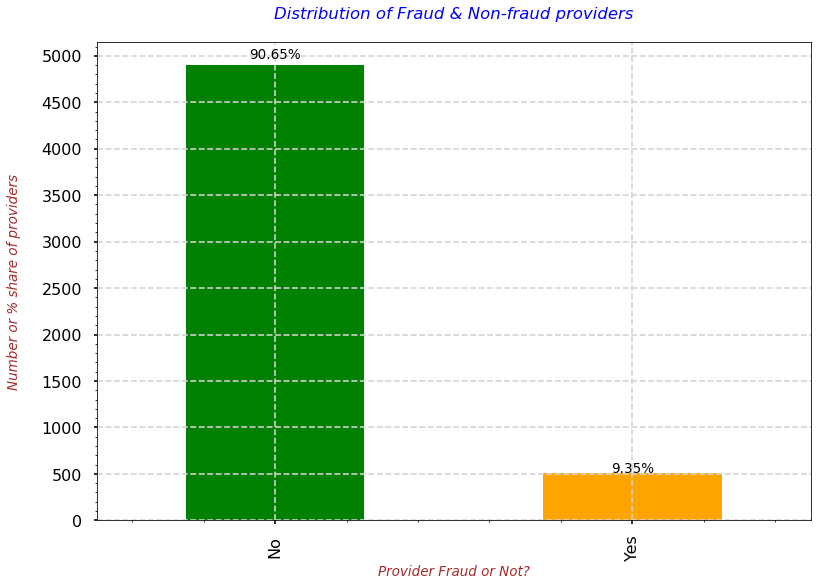

```python
with plt.style.context('seaborn-poster'):
    fig = train_tgt_lbls_df["PotentialFraud"].value_counts().plot(kind='bar', color=['green','orange'])
    # Using the "patches" function we will get the location of the rectangle bars from the graph.
    ## Then by using those location(width & height) values we will add the annotations
    for p in fig.patches:
        width = p.get_width()
        height = p.get_height()
        x, y = p.get_xy()
        fig.annotate(f'{str(round((height*100)/train_tgt_lbls_df.shape[0],2))+"%"}', (x + width/2, y + height*1.015), ha='center', fontsize=13.5)
    # Providing the labels and title to the graph
    plt.xlabel("Provider Fraud or Not?", fontdict=label_font_dict)
    plt.ylabel("Number or % share of providers\n", fontdict=label_font_dict)
    plt.yticks(np.arange(0,5100,500))
    plt.grid(which='major', linestyle="--", color='lightgrey')
    plt.minorticks_on()
    plt.title("Distribution of Fraud & Non-fraud providers\n", fontdict=title_font_dict)
    plt.plot();
```

**`OBSERVATION`**

- From the above plot, we can say that 90% of the providers are not frausters and only 9% of them are involved in frauds.

### **Adding the `Admitted` or `Not Admitted` indicator in IP and OP Dataset**

- **Adding in IP Dataset**

```python
train_ip_df["Admitted?"] = 1
```

```python
train_ip_df.head()
```

|  | BeneID | ClaimID | ClaimStartDt | ClaimEndDt | Provider | InscClaimAmtReimbursed | AttendingPhysician | OperatingPhysician | OtherPhysician | AdmissionDt | ClmAdmitDiagnosisCode | DeductibleAmtPaid | DischargeDt | DiagnosisGroupCode | ClmDiagnosisCode_1 | ClmDiagnosisCode_2 | ClmDiagnosisCode_3 | ClmDiagnosisCode_4 | ClmDiagnosisCode_5 | ClmDiagnosisCode_6 | ClmDiagnosisCode_7 | ClmDiagnosisCode_8 | ClmDiagnosisCode_9 | ClmDiagnosisCode_10 | ClmProcedureCode_1 | ClmProcedureCode_2 | ClmProcedureCode_3 | ClmProcedureCode_4 | ClmProcedureCode_5 | … |
| --- | --- | --- | --- | --- | --- | --- | --- | --- | --- | --- | --- | --- | --- | --- | --- | --- | --- | --- | --- | --- | --- | --- | --- | --- | --- | --- | --- | --- | --- | --- |
| 0 | BENE11001 | CLM46614 | 2009-04-12 | 2009-04-18 | PRV55912 | 26000 | PHY390922 | NaN | NaN | 2009-04-12 | 7866 | 1068.0 | 2009-04-18 | 201 | 1970 | 4019 | 5853 | 7843 | 2768 | 71590 | 2724 | 19889 | 5849 | NaN | NaN | NaN | NaN | NaN | NaN | … |
| 1 | BENE11001 | CLM66048 | 2009-08-31 | 2009-09-02 | PRV55907 | 5000 | PHY318495 | PHY318495 | NaN | 2009-08-31 | 6186 | 1068.0 | 2009-09-02 | 750 | 6186 | 2948 | 56400 | NaN | NaN | NaN | NaN | NaN | NaN | NaN | 7092.0 | NaN | NaN | NaN | NaN | … |
| 2 | BENE11001 | CLM68358 | 2009-09-17 | 2009-09-20 | PRV56046 | 5000 | PHY372395 | NaN | PHY324689 | 2009-09-17 | 29590 | 1068.0 | 2009-09-20 | 883 | 29623 | 30390 | 71690 | 34590 | V1581 | 32723 | NaN | NaN | NaN | NaN | NaN | NaN | NaN | NaN | NaN | … |
| 3 | BENE11011 | CLM38412 | 2009-02-14 | 2009-02-22 | PRV52405 | 5000 | PHY369659 | PHY392961 | PHY349768 | 2009-02-14 | 431 | 1068.0 | 2009-02-22 | 067 | 43491 | 2762 | 7843 | 32723 | V1041 | 4254 | 25062 | 40390 | 4019 | NaN | 331.0 | NaN | NaN | NaN | NaN | … |
| 4 | BENE11014 | CLM63689 | 2009-08-13 | 2009-08-30 | PRV56614 | 10000 | PHY379376 | PHY398258 | NaN | 2009-08-13 | 78321 | 1068.0 | 2009-08-30 | 975 | 042 | 3051 | 34400 | 5856 | 42732 | 486 | 5119 | 29620 | 20300 | NaN | 3893.0 | NaN | NaN | NaN | NaN | … |

- **Adding in OP Dataset**

```python
train_op_df["Admitted?"] = 0
```

```python
train_op_df.head()
```

|  | BeneID | ClaimID | ClaimStartDt | ClaimEndDt | Provider | InscClaimAmtReimbursed | AttendingPhysician | OperatingPhysician | OtherPhysician | ClmDiagnosisCode_1 | ClmDiagnosisCode_2 | ClmDiagnosisCode_3 | ClmDiagnosisCode_4 | ClmDiagnosisCode_5 | ClmDiagnosisCode_6 | ClmDiagnosisCode_7 | ClmDiagnosisCode_8 | ClmDiagnosisCode_9 | ClmDiagnosisCode_10 | ClmProcedureCode_1 | ClmProcedureCode_2 | ClmProcedureCode_3 | ClmProcedureCode_4 | ClmProcedureCode_5 | ClmProcedureCode_6 | DeductibleAmtPaid | ClmAdmitDiagnosisCode | Admitted? |
| --- | --- | --- | --- | --- | --- | --- | --- | --- | --- | --- | --- | --- | --- | --- | --- | --- | --- | --- | --- | --- | --- | --- | --- | --- | --- | --- | --- | --- |
| 0 | BENE11002 | CLM624349 | 2009-10-11 | 2009-10-11 | PRV56011 | 30 | PHY326117 | NaN | NaN | 78943 | V5866 | V1272 | NaN | NaN | NaN | NaN | NaN | NaN | NaN | NaN | NaN | NaN | NaN | NaN | NaN | 0 | 56409 | 0 |
| 1 | BENE11003 | CLM189947 | 2009-02-12 | 2009-02-12 | PRV57610 | 80 | PHY362868 | NaN | NaN | 6115 | NaN | NaN | NaN | NaN | NaN | NaN | NaN | NaN | NaN | NaN | NaN | NaN | NaN | NaN | NaN | 0 | 79380 | 0 |
| 2 | BENE11003 | CLM438021 | 2009-06-27 | 2009-06-27 | PRV57595 | 10 | PHY328821 | NaN | NaN | 2723 | NaN | NaN | NaN | NaN | NaN | NaN | NaN | NaN | NaN | NaN | NaN | NaN | NaN | NaN | NaN | 0 | NaN | 0 |
| 3 | BENE11004 | CLM121801 | 2009-01-06 | 2009-01-06 | PRV56011 | 40 | PHY334319 | NaN | NaN | 71988 | NaN | NaN | NaN | NaN | NaN | NaN | NaN | NaN | NaN | NaN | NaN | NaN | NaN | NaN | NaN | 0 | NaN | 0 |
| 4 | BENE11004 | CLM150998 | 2009-01-22 | 2009-01-22 | PRV56011 | 200 | PHY403831 | NaN | NaN | 82382 | 30000 | 72887 | 4280 | 7197 | V4577 | NaN | NaN | NaN | NaN | NaN | NaN | NaN | NaN | NaN | NaN | 0 | 71947 | 0 |

### **Merging the Datasets**

```python
# Commom columns must be 28
common_cols = [col for col in train_ip_df.columns if col in train_op_df.columns]
len(common_cols)
```

```
28
```

```python
# Merging the IP and OP dataset on the basis of common columns
train_ip_op_df = pd.merge(left=train_ip_df, right=train_op_df, left_on=common_cols, right_on=common_cols, how="outer")
train_ip_op_df.shape
```

```
(558211, 31)
```

```python
train_ip_op_df.head()
```

|  | BeneID | ClaimID | ClaimStartDt | ClaimEndDt | Provider | InscClaimAmtReimbursed | AttendingPhysician | OperatingPhysician | OtherPhysician | AdmissionDt | ClmAdmitDiagnosisCode | DeductibleAmtPaid | DischargeDt | DiagnosisGroupCode | ClmDiagnosisCode_1 | ClmDiagnosisCode_2 | ClmDiagnosisCode_3 | ClmDiagnosisCode_4 | ClmDiagnosisCode_5 | ClmDiagnosisCode_6 | ClmDiagnosisCode_7 | ClmDiagnosisCode_8 | ClmDiagnosisCode_9 | ClmDiagnosisCode_10 | ClmProcedureCode_1 | ClmProcedureCode_2 | ClmProcedureCode_3 | ClmProcedureCode_4 | ClmProcedureCode_5 | … |
| --- | --- | --- | --- | --- | --- | --- | --- | --- | --- | --- | --- | --- | --- | --- | --- | --- | --- | --- | --- | --- | --- | --- | --- | --- | --- | --- | --- | --- | --- | --- |
| 0 | BENE11001 | CLM46614 | 2009-04-12 | 2009-04-18 | PRV55912 | 26000 | PHY390922 | NaN | NaN | 2009-04-12 | 7866 | 1068.0 | 2009-04-18 | 201 | 1970 | 4019 | 5853 | 7843 | 2768 | 71590 | 2724 | 19889 | 5849 | NaN | NaN | NaN | NaN | NaN | NaN | … |
| 1 | BENE11001 | CLM66048 | 2009-08-31 | 2009-09-02 | PRV55907 | 5000 | PHY318495 | PHY318495 | NaN | 2009-08-31 | 6186 | 1068.0 | 2009-09-02 | 750 | 6186 | 2948 | 56400 | NaN | NaN | NaN | NaN | NaN | NaN | NaN | 7092.0 | NaN | NaN | NaN | NaN | … |
| 2 | BENE11001 | CLM68358 | 2009-09-17 | 2009-09-20 | PRV56046 | 5000 | PHY372395 | NaN | PHY324689 | 2009-09-17 | 29590 | 1068.0 | 2009-09-20 | 883 | 29623 | 30390 | 71690 | 34590 | V1581 | 32723 | NaN | NaN | NaN | NaN | NaN | NaN | NaN | NaN | NaN | … |
| 3 | BENE11011 | CLM38412 | 2009-02-14 | 2009-02-22 | PRV52405 | 5000 | PHY369659 | PHY392961 | PHY349768 | 2009-02-14 | 431 | 1068.0 | 2009-02-22 | 067 | 43491 | 2762 | 7843 | 32723 | V1041 | 4254 | 25062 | 40390 | 4019 | NaN | 331.0 | NaN | NaN | NaN | NaN | … |
| 4 | BENE11014 | CLM63689 | 2009-08-13 | 2009-08-30 | PRV56614 | 10000 | PHY379376 | PHY398258 | NaN | 2009-08-13 | 78321 | 1068.0 | 2009-08-30 | 975 | 042 | 3051 | 34400 | 5856 | 42732 | 486 | 5119 | 29620 | 20300 | NaN | 3893.0 | NaN | NaN | NaN | NaN | … |

### **Merging the IP_OP Dataset with BENE Data**

```python
# Joining the IP_OP dataset with the BENE data
train_ip_op_bene_df = pd.merge(left=train_ip_op_df, right=train_bene_df, left_on='BeneID', right_on='BeneID',how='inner')
train_ip_op_bene_df.shape
```

```
(558211, 55)
```

### **Merging the IP_OP_BENE Dataset with PROVIDER level Tgt Labels Data**

```python
# Joining the IP_OP_BENE dataset with the Tgt Label Provider Data
train_iobp_df = pd.merge(left=train_ip_op_bene_df, right=train_tgt_lbls_df, left_on='Provider', right_on='Provider',how='inner')
train_iobp_df.shape
```

```
(558211, 56)
```

### **Entire Dataset**

```python
train_iobp_df.shape
```

```
(558211, 56)
```

```python
# Unique Providers
train_iobp_df["Provider"].nunique()
```

```
5410
```

```python
# Unique Claim numbers
train_iobp_df["ClaimID"].nunique()
```

```
558211
```

### *`ASSUMPTION`* :: One provider may have been involved in more than one claim. So, does all the claims filed by a potentially fraud provider are all frauds?

```
- This cannot holds True for all the providers because if one provider has filed say 50 claims then we can't say that all the claims for that provider are fraudulent.
    - There may exists a pattern that out of 50 claims a provider files 1 or 2 fraudulent claims.
```

#### **`Therefore, it is a big assumption to make that all the claims filed by a potentially fraud provider are fraudulent.`**

```python
prvs_claims_df = pd.DataFrame(train_iobp_df.groupby(['Provider'])['ClaimID'].count()).reset_index()
prvs_claims_tgt_lbls_df = pd.merge(left=prvs_claims_df, right=train_tgt_lbls_df, on='Provider', how='inner')
prvs_claims_tgt_lbls_df
```

|  | Provider | ClaimID | PotentialFraud |
| --- | --- | --- | --- |
| 0 | PRV51001 | 25 | No |
| 1 | PRV51003 | 132 | Yes |
| 2 | PRV51004 | 149 | No |
| 3 | PRV51005 | 1165 | Yes |
| 4 | PRV51007 | 72 | No |
| ... | ... | ... | ... |
| 5405 | PRV57759 | 28 | No |
| 5406 | PRV57760 | 22 | No |
| 5407 | PRV57761 | 82 | No |
| 5408 | PRV57762 | 1 | No |
| 5409 | PRV57763 | 118 | No |

5410 rows × 3 columns

**`OBSERVATION`**

- As shown in the above table, PRV51005 has filed 1165 claims so after joining the datasets all of these will be marked as Fraud.
- **Fraud Count at Claims level**

```
     PotentialFraud
No           345415
Yes          212796
```

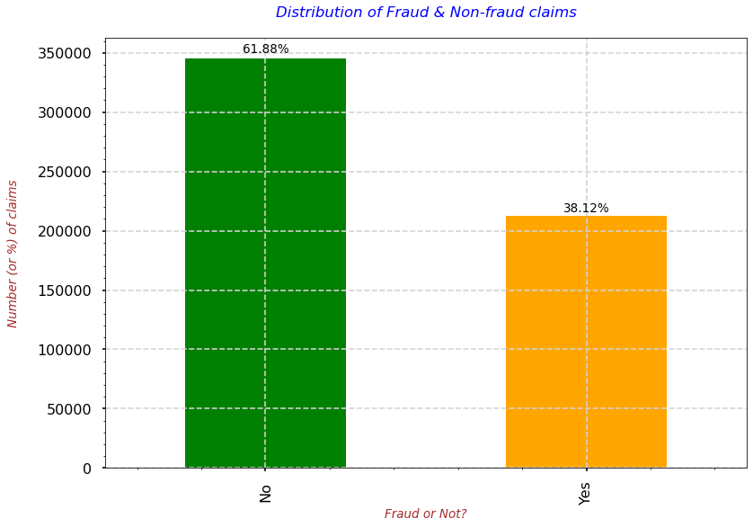

```python
print(pd.DataFrame(train_iobp_df['PotentialFraud'].value_counts()), "\n")

with plt.style.context('seaborn-poster'):
    fig = train_iobp_df['PotentialFraud'].value_counts().plot(kind='bar', color=['green','orange'])
    # Using the "patches" function we will get the location of the rectangle bars from the graph.
    ## Then by using those location(width & height) values we will add the annotations
    for p in fig.patches:
        width = p.get_width()
        height = p.get_height()
        x, y = p.get_xy()
        fig.annotate(f'{str(round((height*100)/train_iobp_df.shape[0],2))+"%"}', (x + width/2, y + height*1.015), ha='center', fontsize=13.5)
    # Providing the labels and title to the graph
    plt.xlabel("Fraud or Not?", fontdict=label_font_dict)
    plt.ylabel("Number (or %) of claims\n", fontdict=label_font_dict)
    plt.grid(which='major', linestyle="--", color='lightgrey')
    plt.minorticks_on()
    plt.title("Distribution of Fraud & Non-fraud claims\n", fontdict=title_font_dict)
    plt.plot();
```

**`OBSERVATION`**

## **Feature Engineering + Impact Analysis**

**`Let's create some features`**

### **Adding `New Feature` :: `Is_Alive?`**

```
- Is Alive? = No if DOD is NaN else Yes
```

```python
train_iobp_df['DOB'] = pd.to_datetime(train_iobp_df['DOB'], format="%Y-%m-%d")
train_iobp_df['DOD'] = pd.to_datetime(train_iobp_df['DOD'], format="%Y-%m-%d")
```

```python
train_iobp_df['Is_Alive?'] = train_iobp_df['DOD'].apply(lambda val: 'No' if val != val else 'Yes')
```

```python
train_iobp_df['Is_Alive?'].value_counts()
```

```
No     554080
Yes      4131
Name: Is_Alive?, dtype: int64
```

### **Adding `New Feature` :: `Claim_Duration`**

```
- Claim Duration = Claim End Date - Claim Start Date
```

```python
train_iobp_df['ClaimStartDt'] = pd.to_datetime(train_iobp_df['ClaimStartDt'], format="%Y-%m-%d")
train_iobp_df['ClaimEndDt'] = pd.to_datetime(train_iobp_df['ClaimEndDt'], format="%Y-%m-%d")

train_iobp_df['Claim_Duration'] = (train_iobp_df['ClaimEndDt'] - train_iobp_df['ClaimStartDt']).dt.days
```

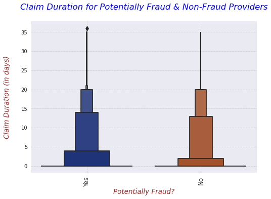

```python
with plt.style.context('seaborn'):
    fig = sns.boxenplot(data=train_iobp_df, x='PotentialFraud',y='Claim_Duration', palette='dark')
    # Providing the labels and title to the graph
    plt.xlabel("Potentially Fraud?", fontdict=label_font_dict)
    plt.xticks(rotation=90, fontsize=12)
    plt.ylabel("Claim Duration (in days)\n", fontdict=label_font_dict)
    plt.minorticks_on()
    plt.grid(which='major', linestyle="--", color='lightgrey')
    plt.title("Claim Duration for Potentially Fraud & Non-Fraud Providers\n", fontdict=title_font_dict)
    plt.plot();
```

**`OBSERVATION`**

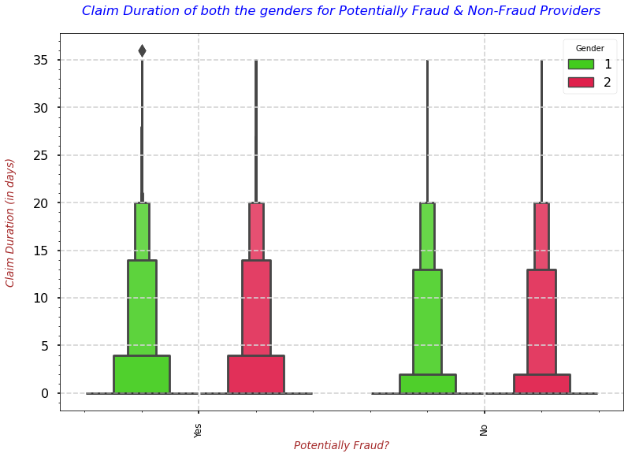

```python
with plt.style.context('seaborn-poster'):
    fig = sns.boxenplot(data=train_iobp_df, x='PotentialFraud',y='Claim_Duration', hue='Gender', palette='prism')
    # Providing the labels and title to the graph
    plt.xlabel("Potentially Fraud?", fontdict=label_font_dict)
    plt.xticks(rotation=90, fontsize=12)
    plt.ylabel("Claim Duration (in days)\n", fontdict=label_font_dict)
    plt.minorticks_on()
    plt.grid(which='major', linestyle="--", color='lightgrey')
    plt.title("Claim Duration of both the genders for Potentially Fraud & Non-Fraud Providers\n", fontdict=title_font_dict)
    plt.plot();
```

**`OBSERVATION`**

- The above plot clearly shows us that there is no difference in the distribution of Claim Duration of males and females for Potentially Fraud and Non-Fraud Providers.
  - Therefore, we can say that Claim Duration might not be useful in segregating the Fraud cases.
- **Relationship b/w `Claim_Duration` and `Potentially Fraud` for `Is_Alive?`**

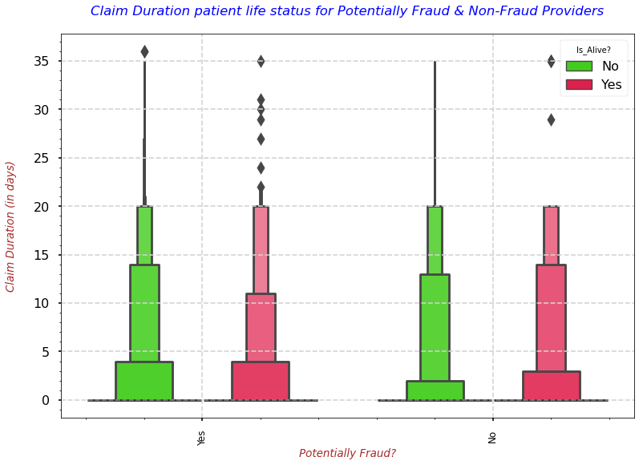

```python
with plt.style.context('seaborn-poster'):
    fig = sns.boxenplot(data=train_iobp_df, x='PotentialFraud',y='Claim_Duration', hue='Is_Alive?', palette='prism')
    # Providing the labels and title to the graph
    plt.xlabel("Potentially Fraud?", fontdict=label_font_dict)
    plt.xticks(rotation=90, fontsize=12)
    plt.ylabel("Claim Duration (in days)\n", fontdict=label_font_dict)
    plt.minorticks_on()
    plt.grid(which='major', linestyle="--", color='lightgrey')
    plt.title("Claim Duration patient life status for Potentially Fraud & Non-Fraud Providers\n", fontdict=title_font_dict)
    plt.plot();
```

**`OBSERVATION`**

- The above plot clearly shows us that there is no difference in the distribution of Claim Duration on patient life status for Potentially Fraud and Non-Fraud Providers.
  - Therefore, we can say that Claim Duration might not be useful in segregating the Fraud cases.
- **Relationship b/w `Claim_Duration` and `Potentially Fraud` for all `Human Races`**

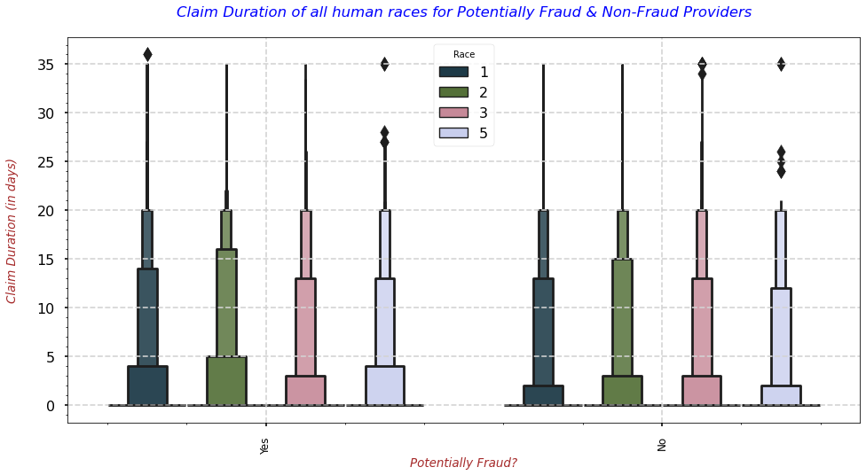

```python
with plt.style.context('seaborn-poster'):
    plt.figure(figsize=(16,8))
    fig = sns.boxenplot(data=train_iobp_df, x='PotentialFraud',y='Claim_Duration', hue='Race', palette='cubehelix')
    # Providing the labels and title to the graph
    plt.xlabel("Potentially Fraud?", fontdict=label_font_dict)
    plt.xticks(rotation=90, fontsize=12)
    plt.ylabel("Claim Duration (in days)\n", fontdict=label_font_dict)
    plt.minorticks_on()
    plt.grid(which='major', linestyle="--", color='lightgrey')
    plt.title("Claim Duration of all human races for Potentially Fraud & Non-Fraud Providers\n", fontdict=title_font_dict)
    plt.legend(loc='upper center',title='Race');
```

**`OBSERVATION`**

- The above plot clearly shows us that there is no difference in the distribution of Claim Duration of all human races for Potentially Fraud and Non-Fraud Providers.
  - Therefore, we can say that Claim Duration might not be useful in segregating the Fraud cases.
- **Relationship b/w `Claim_Duration` and `Potentially Fraud` for `RenalDiseaseIndicator`**

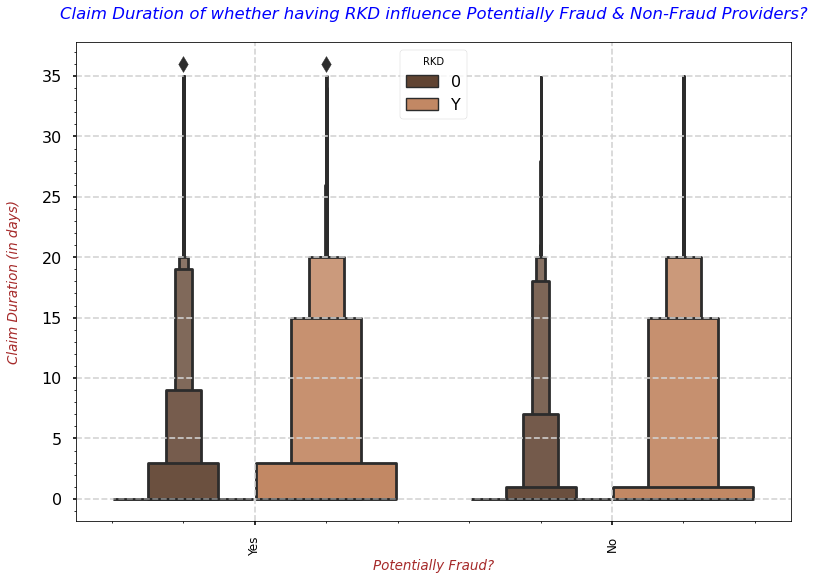

```python
with plt.style.context('seaborn-poster'):
    fig = sns.boxenplot(data=train_iobp_df, x='PotentialFraud',y='Claim_Duration', hue='RenalDiseaseIndicator', palette='copper')
    # Providing the labels and title to the graph
    plt.xlabel("Potentially Fraud?", fontdict=label_font_dict)
    plt.xticks(rotation=90, fontsize=12)
    plt.ylabel("Claim Duration (in days)\n", fontdict=label_font_dict)
    plt.minorticks_on()
    plt.grid(which='major', linestyle="--", color='lightgrey')
    plt.title("Claim Duration of whether having RKD influence Potentially Fraud & Non-Fraud Providers?\n", fontdict=title_font_dict)
    plt.legend(loc="upper center", title='RKD');
```

**`OBSERVATION`**

### **Adding `New Feature` :: `Admitted_Duration`**

```
- Admitted Duration = Discharge Date - Admission Date
```

```python
train_iobp_df['AdmissionDt'] = pd.to_datetime(train_iobp_df['AdmissionDt'], format="%Y-%m-%d")
train_iobp_df['DischargeDt'] = pd.to_datetime(train_iobp_df['DischargeDt'], format="%Y-%m-%d")

train_iobp_df['Admitted_Duration'] = (train_iobp_df['DischargeDt'] - train_iobp_df['AdmissionDt']).dt.days
```

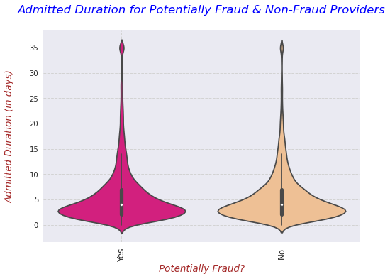

```python
with plt.style.context('seaborn'):
    fig = sns.violinplot(data=train_iobp_df, x='PotentialFraud',y='Admitted_Duration', palette='Accent_r')
    # Providing the labels and title to the graph
    plt.xlabel("Potentially Fraud?", fontdict=label_font_dict)
    plt.xticks(rotation=90, fontsize=12)
    plt.ylabel("Admitted Duration (in days)\n", fontdict=label_font_dict)
    plt.minorticks_on()
    plt.grid(which='major', linestyle="--", color='lightgrey')
    plt.title("Admitted Duration for Potentially Fraud & Non-Fraud Providers\n", fontdict=title_font_dict)
    plt.plot();
```

**`OBSERVATION`**

- The above plot clearly shows us that there is no difference in the distribution of Admit Duration for Potentially Fraud and Non-Fraud Providers.
  - Therefore, we can say that Admit Duration alone might not be useful in segregating the Fraud cases.
- **Relationship b/w `Admit_Duration` and `Potentially Fraud` for both the `Genders`**

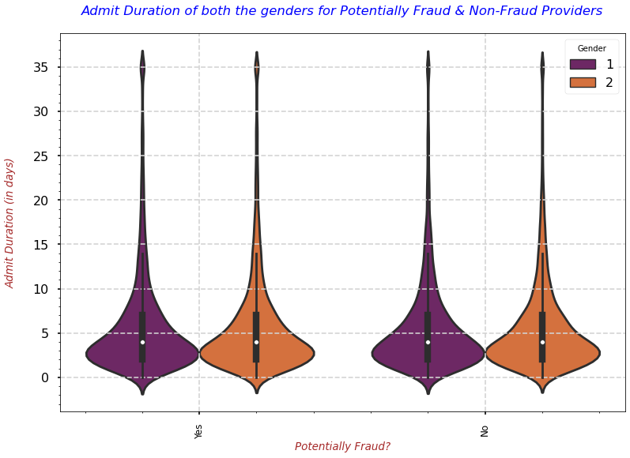

```python
with plt.style.context('seaborn-poster'):
    fig = sns.violinplot(data=train_iobp_df, x='PotentialFraud',y='Admitted_Duration', hue='Gender', palette='inferno')
    # Providing the labels and title to the graph
    plt.xlabel("Potentially Fraud?", fontdict=label_font_dict)
    plt.xticks(rotation=90, fontsize=12)
    plt.ylabel("Admit Duration (in days)\n", fontdict=label_font_dict)
    plt.minorticks_on()
    plt.grid(which='major', linestyle="--", color='lightgrey')
    plt.title("Admit Duration of both the genders for Potentially Fraud & Non-Fraud Providers\n", fontdict=title_font_dict)
    plt.plot();
```

**`OBSERVATION`**

- The above plot clearly shows us that there is no difference in the distribution of Admit Duration of males and females for Potentially Fraud and Non-Fraud Providers.
  - Therefore, we can say that Admit Duration might not be useful in segregating the Fraud cases.
- **Relationship b/w `Admitted_Duration` and `Potentially Fraud` for `Is_Alive?`**

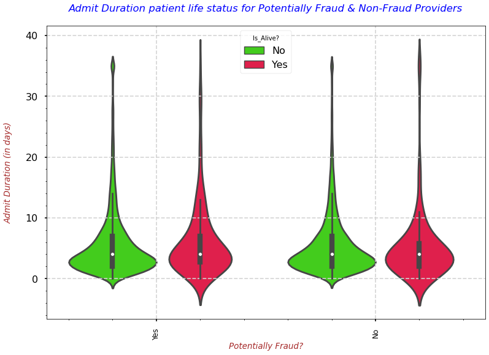

```python
with plt.style.context('seaborn-poster'):
    fig = sns.violinplot(data=train_iobp_df, x='PotentialFraud',y='Admitted_Duration', hue='Is_Alive?', palette='prism')
    # Providing the labels and title to the graph
    plt.xlabel("Potentially Fraud?", fontdict=label_font_dict)
    plt.xticks(rotation=90, fontsize=12)
    plt.ylabel("Admit Duration (in days)\n", fontdict=label_font_dict)
    plt.minorticks_on()
    plt.grid(which='major', linestyle="--", color='lightgrey')
    plt.title("Admit Duration patient life status for Potentially Fraud & Non-Fraud Providers\n", fontdict=title_font_dict)
    plt.legend(loc="upper center", title='Is_Alive?');
```

**`OBSERVATION`**

- The above plot clearly shows us that there is no difference in the distribution of Admit Duration on patient life status for Potentially Fraud and Non-Fraud Providers.
  - Therefore, we can say that Admit Duration might not be useful in segregating the Fraud cases.
- **Relationship b/w `Admit_Duration` and `Potentially Fraud` for all `Human Races`**

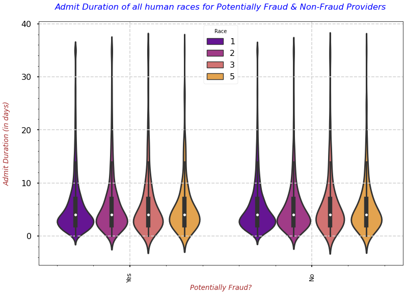

```python
with plt.style.context('seaborn-poster'):
    fig = sns.violinplot(data=train_iobp_df, x='PotentialFraud',y='Admitted_Duration', hue='Race', palette='plasma')
    # Providing the labels and title to the graph
    plt.xlabel("Potentially Fraud?", fontdict=label_font_dict)
    plt.xticks(rotation=90, fontsize=12)
    plt.ylabel("Admit Duration (in days)\n", fontdict=label_font_dict)
    plt.minorticks_on()
    plt.grid(which='major', linestyle="--", color='lightgrey')
    plt.title("Admit Duration of all human races for Potentially Fraud & Non-Fraud Providers\n", fontdict=title_font_dict)
    plt.legend(loc="upper center", title="Race");
```

**`OBSERVATION`**

- The above plot clearly shows us that there is no difference in the distribution of Admit Duration of all human races for Potentially Fraud and Non-Fraud Providers.
  - Therefore, we can say that Admit Duration might not be useful in segregating the Fraud cases.
- **Relationship b/w `Admitted_Duration` and `Potentially Fraud` for `RenalDiseaseIndicator`**

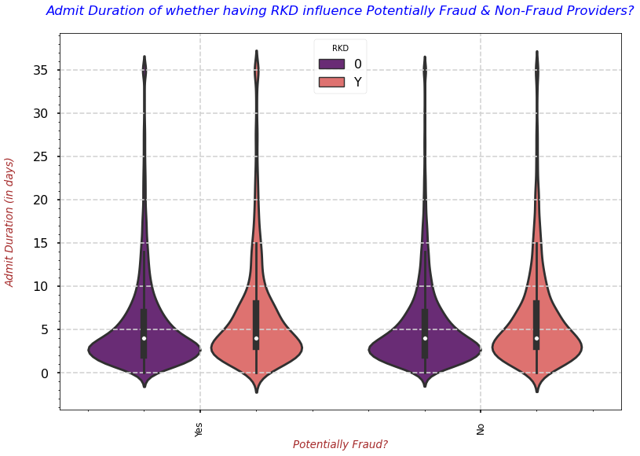

```python
with plt.style.context('seaborn-poster'):
    fig = sns.violinplot(data=train_iobp_df, x='PotentialFraud',y='Admitted_Duration', hue='RenalDiseaseIndicator',palette='magma')
    # Providing the labels and title to the graph
    plt.xlabel("Potentially Fraud?", fontdict=label_font_dict)
    plt.xticks(rotation=90, fontsize=12)
    plt.ylabel("Admit Duration (in days)\n", fontdict=label_font_dict)
    plt.minorticks_on()
    plt.grid(which='major', linestyle="--", color='lightgrey')
    plt.title("Admit Duration of whether having RKD influence Potentially Fraud & Non-Fraud Providers?\n", fontdict=title_font_dict)
    plt.legend(loc="upper center", title="RKD");
```

**`OBSERVATION`**

- The above plot clearly shows us that there is no difference in the distribution of Admit Duration of patients with or w/o RKD for Potentially Fraud and Non-Fraud Providers.
  - Therefore, we can say that Admit Duration might not be useful in segregating the Fraud cases.

### **Adding `New Feature` :: `Bene_Age`**

```
- Bene Age = DOD - DOB (if DOD is Null then replace it with MAX date in DOD)
```

```python
# Filling the Null values as MAX Date of Death in the Dataset
train_iobp_df['DOD'].fillna(value=train_iobp_df['DOD'].max(), inplace=True)
```

```python
train_iobp_df['Bene_Age'] = round(((train_iobp_df['DOD'] - train_iobp_df['DOB']).dt.days)/365,1)
```

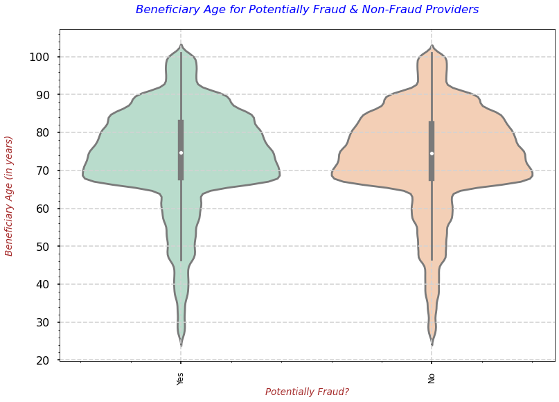

```python
with plt.style.context('seaborn-poster'):
    fig = sns.violinplot(data=train_iobp_df, x='PotentialFraud',y='Bene_Age', palette='Pastel2')
    # Providing the labels and title to the graph
    plt.xlabel("Potentially Fraud?", fontdict=label_font_dict)
    plt.xticks(rotation=90, fontsize=12)
    plt.ylabel("Beneficiary Age (in years)\n", fontdict=label_font_dict)
    plt.minorticks_on()
    plt.grid(which='major', linestyle="--", color='lightgrey')
    plt.title("Beneficiary Age for Potentially Fraud & Non-Fraud Providers\n", fontdict=title_font_dict)
    plt.plot();
```

**`OBSERVATION`**

- The above plot clearly shows us that there is no difference in the distribution of Beneficiary Age for Potentially Fraud and Non-Fraud Providers.
  - Therefore, we can say that Beneficiary Age alone might not be useful in segregating the Fraud cases.
- **Relationship b/w `Bene_Age` and `Potentially Fraud` for both the `Genders`**

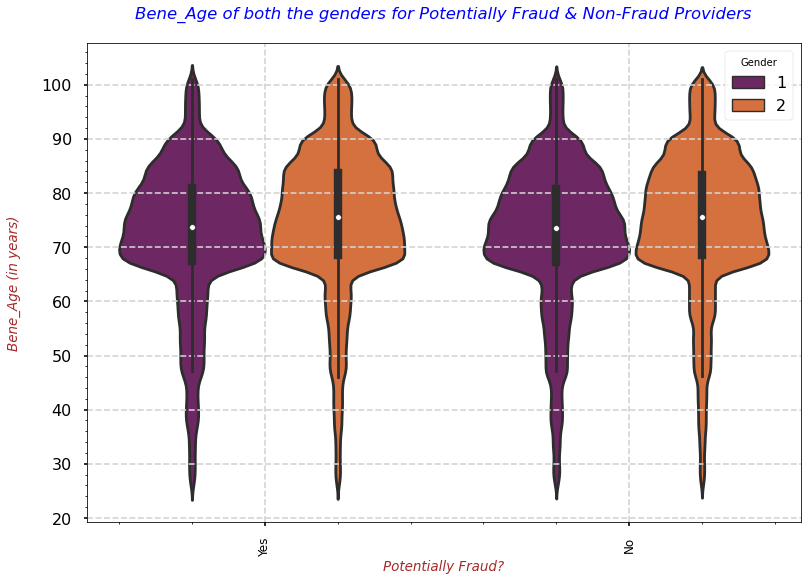

```python
with plt.style.context('seaborn-poster'):
    fig = sns.violinplot(data=train_iobp_df, x='PotentialFraud',y='Bene_Age', hue='Gender', palette='inferno')
    # Providing the labels and title to the graph
    plt.xlabel("Potentially Fraud?", fontdict=label_font_dict)
    plt.xticks(rotation=90, fontsize=12)
    plt.ylabel("Bene_Age (in years)\n", fontdict=label_font_dict)
    plt.minorticks_on()
    plt.grid(which='major', linestyle="--", color='lightgrey')
    plt.title("Bene_Age of both the genders for Potentially Fraud & Non-Fraud Providers\n", fontdict=title_font_dict)
    plt.plot();
```

**`OBSERVATION`**

- The above plot clearly shows us that there is no difference in the distribution of Bene_Age of males and females for Potentially Fraud and Non-Fraud Providers.
  - Therefore, we can say that Bene_Age might not be useful in segregating the Fraud cases.
- **Relationship b/w `Bene_Age` and `Potentially Fraud` for `Is_Alive?`**

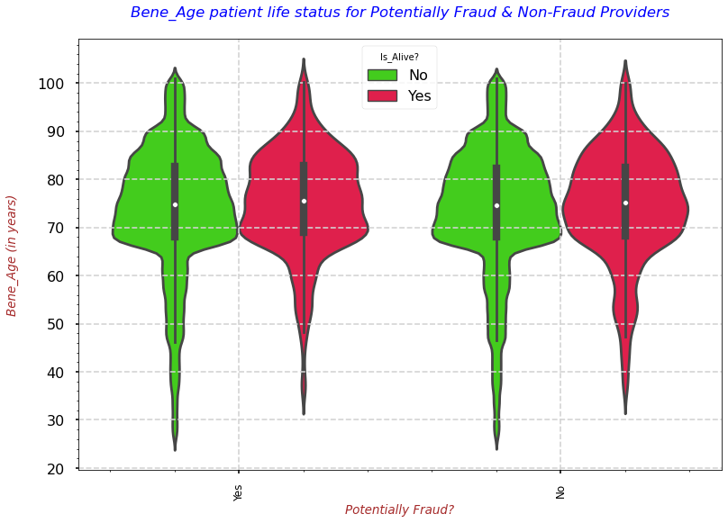

```python
with plt.style.context('seaborn-poster'):
    fig = sns.violinplot(data=train_iobp_df, x='PotentialFraud',y='Bene_Age', hue='Is_Alive?', palette='prism')
    # Providing the labels and title to the graph
    plt.xlabel("Potentially Fraud?", fontdict=label_font_dict)
    plt.xticks(rotation=90, fontsize=12)
    plt.ylabel("Bene_Age (in years)\n", fontdict=label_font_dict)
    plt.minorticks_on()
    plt.grid(which='major', linestyle="--", color='lightgrey')
    plt.title("Bene_Age patient life status for Potentially Fraud & Non-Fraud Providers\n", fontdict=title_font_dict)
    plt.legend(loc="upper center", title='Is_Alive?');
```

**`OBSERVATION`**

- The above plot clearly shows us that there is no difference in the distribution of Bene_Age on patient life status for Potentially Fraud and Non-Fraud Providers.
  - Therefore, we can say that Bene_Age might not be useful in segregating the Fraud cases.
- **Relationship b/w `Bene_Age` and `Potentially Fraud` for all `Human Races`**

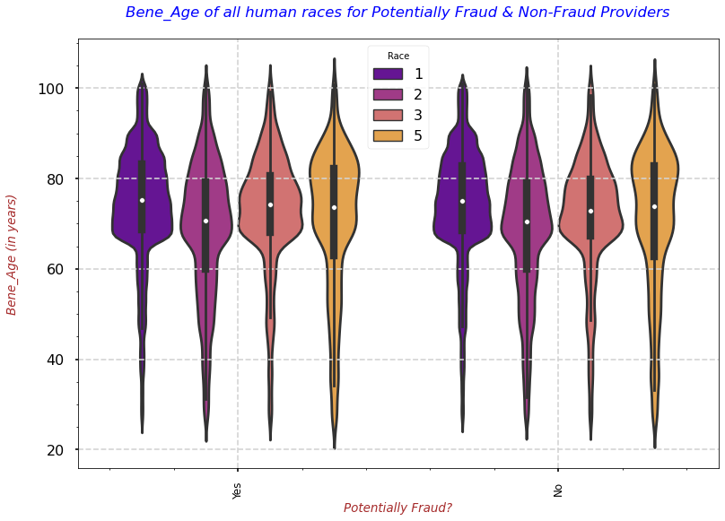

```python
with plt.style.context('seaborn-poster'):
    fig = sns.violinplot(data=train_iobp_df, x='PotentialFraud',y='Bene_Age', hue='Race', palette='plasma')
    # Providing the labels and title to the graph
    plt.xlabel("Potentially Fraud?", fontdict=label_font_dict)
    plt.xticks(rotation=90, fontsize=12)
    plt.ylabel("Bene_Age (in years)\n", fontdict=label_font_dict)
    plt.minorticks_on()
    plt.grid(which='major', linestyle="--", color='lightgrey')
    plt.title("Bene_Age of all human races for Potentially Fraud & Non-Fraud Providers\n", fontdict=title_font_dict)
    plt.legend(loc="upper center", title="Race");
```

**`OBSERVATION`**

- The above plot clearly shows us that there is no difference in the distribution of Bene_Age of all human races for Potentially Fraud and Non-Fraud Providers.
  - Therefore, we can say that Bene_Age might not be useful in segregating the Fraud cases.
- **Relationship b/w `Bene_Age` and `Potentially Fraud` for `RenalDiseaseIndicator`**

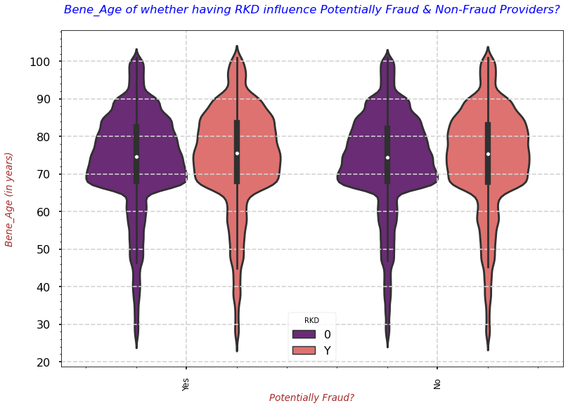

```python
with plt.style.context('seaborn-poster'):
    fig = sns.violinplot(data=train_iobp_df, x='PotentialFraud',y='Bene_Age', hue='RenalDiseaseIndicator',palette='magma')
    # Providing the labels and title to the graph
    plt.xlabel("Potentially Fraud?", fontdict=label_font_dict)
    plt.xticks(rotation=90, fontsize=12)
    plt.ylabel("Bene_Age (in years)\n", fontdict=label_font_dict)
    plt.minorticks_on()
    plt.grid(which='major', linestyle="--", color='lightgrey')
    plt.title("Bene_Age of whether having RKD influence Potentially Fraud & Non-Fraud Providers?\n", fontdict=title_font_dict)
    plt.legend(loc='lower center', title='RKD');
```

**`OBSERVATION`**

- The above plot clearly shows us that there is no difference in the distribution of Bene_Age of patients with or w/o RKD for Potentially Fraud and Non-Fraud Providers.
  - Therefore, we can say that Bene_Age might not be useful in segregating the Fraud cases.

### **Does `InscClaimAmtReimbursed` influences `Potentially Fraud`?**

- **Relationship b/w `InscClaimAmtReimbursed` and `Potentially Fraud`**

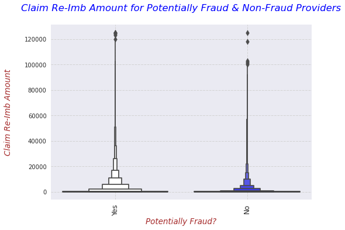

```python
with plt.style.context('seaborn'):
    fig = sns.boxenplot(data=train_iobp_df, x='PotentialFraud',y='InscClaimAmtReimbursed', palette='flag')
    # Providing the labels and title to the graph
    plt.xlabel("Potentially Fraud?", fontdict=label_font_dict)
    plt.xticks(rotation=90, fontsize=12)
    plt.ylabel("Claim Re-Imb Amount\n", fontdict=label_font_dict)
    plt.minorticks_on()
    plt.grid(which='major', linestyle="--", color='lightgrey')
    plt.title("Claim Re-Imb Amount for Potentially Fraud & Non-Fraud Providers\n", fontdict=title_font_dict)
    plt.plot();
```

**`OBSERVATION`**

- The above plot clearly shows us that there is no difference in the distribution of Claim Re-Imb Amount for Potentially Fraud and Non-Fraud Providers.
  - Therefore, we can say that Claim Re-Imb Amount alone might not be useful in segregating the Fraud cases.
- **Relationship b/w `InscClaimAmtReimbursed` and `Potentially Fraud` for both the `Genders`**

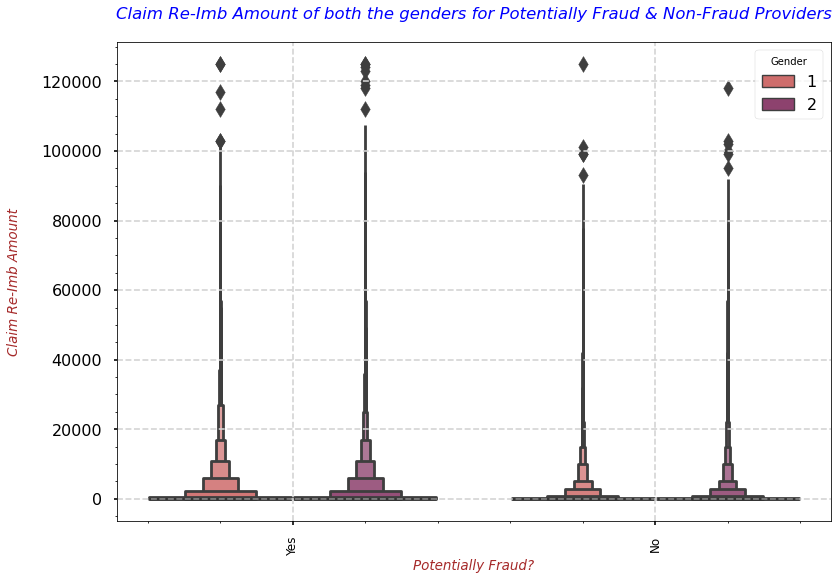

```python
with plt.style.context('seaborn-poster'):
    fig = sns.boxenplot(data=train_iobp_df, x='PotentialFraud',y='InscClaimAmtReimbursed', hue='Gender', palette='flare')
    # Providing the labels and title to the graph
    plt.xlabel("Potentially Fraud?", fontdict=label_font_dict)
    plt.xticks(rotation=90, fontsize=12)
    plt.ylabel("Claim Re-Imb Amount\n", fontdict=label_font_dict)
    plt.minorticks_on()
    plt.grid(which='major', linestyle="--", color='lightgrey')
    plt.title("Claim Re-Imb Amount of both the genders for Potentially Fraud & Non-Fraud Providers\n", fontdict=title_font_dict)
    plt.plot();
```

**`OBSERVATION`**

- The above plot clearly shows us that there is no difference in the distribution of Claim Re-Imb Amount of males and females for Potentially Fraud and Non-Fraud Providers.
  - Therefore, we can say that Claim Re-Imb Amount might not be useful in segregating the Fraud cases.
- **Relationship b/w `InscClaimAmtReimbursed` and `Potentially Fraud` for `Is_Alive?`**

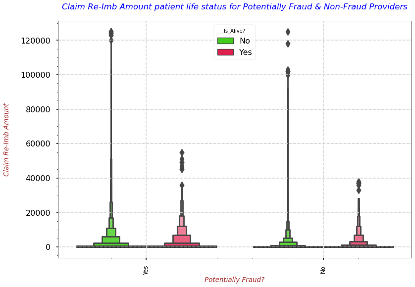

```python
with plt.style.context('seaborn-poster'):
    fig = sns.boxenplot(data=train_iobp_df, x='PotentialFraud',y='InscClaimAmtReimbursed', hue='Is_Alive?', palette='prism')
    # Providing the labels and title to the graph
    plt.xlabel("Potentially Fraud?", fontdict=label_font_dict)
    plt.xticks(rotation=90, fontsize=12)
    plt.ylabel("Claim Re-Imb Amount\n", fontdict=label_font_dict)
    plt.minorticks_on()
    plt.grid(which='major', linestyle="--", color='lightgrey')
    plt.title("Claim Re-Imb Amount patient life status for Potentially Fraud & Non-Fraud Providers\n", fontdict=title_font_dict)
    plt.legend(loc="upper center", title='Is_Alive?');
```

**`OBSERVATION`**

- The above plot clearly shows us that there is no difference in the distribution of Claim Re-Imb Amount on patient life status for Potentially Fraud and Non-Fraud Providers.
  - Therefore, we can say that Claim Re-Imb Amount might not be useful in segregating the Fraud cases.
- **Relationship b/w `InscClaimAmtReimbursed` and `Potentially Fraud` for all `Human Races`**

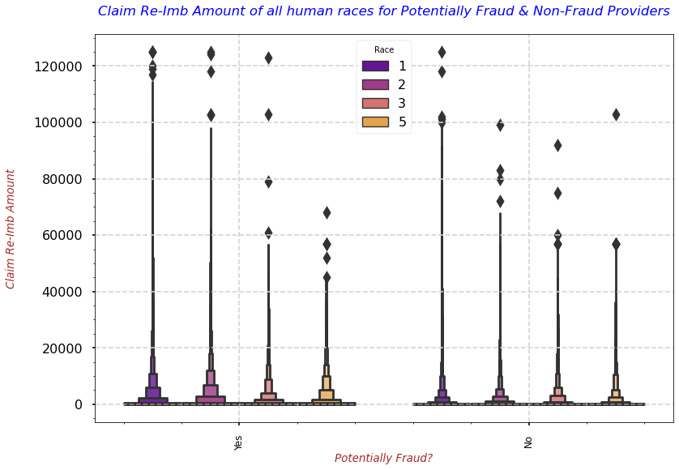

```python
with plt.style.context('seaborn-poster'):
    fig = sns.boxenplot(data=train_iobp_df, x='PotentialFraud',y='InscClaimAmtReimbursed', hue='Race', palette='plasma')
    # Providing the labels and title to the graph
    plt.xlabel("Potentially Fraud?", fontdict=label_font_dict)
    plt.xticks(rotation=90, fontsize=12)
    plt.ylabel("Claim Re-Imb Amount\n", fontdict=label_font_dict)
    plt.minorticks_on()
    plt.grid(which='major', linestyle="--", color='lightgrey')
    plt.title("Claim Re-Imb Amount of all human races for Potentially Fraud & Non-Fraud Providers\n", fontdict=title_font_dict)
    plt.legend(loc="upper center", title="Race");
```

**`OBSERVATION`**

- The above plot clearly shows us that there is no difference in the distribution of Claim Re-Imb Amount of all human races for Potentially Fraud and Non-Fraud Providers.
  - Therefore, we can say that Claim Re-Imb Amount might not be useful in segregating the Fraud cases.
- **Relationship b/w `InscClaimAmtReimbursed` and `Potentially Fraud` for `RenalDiseaseIndicator`**

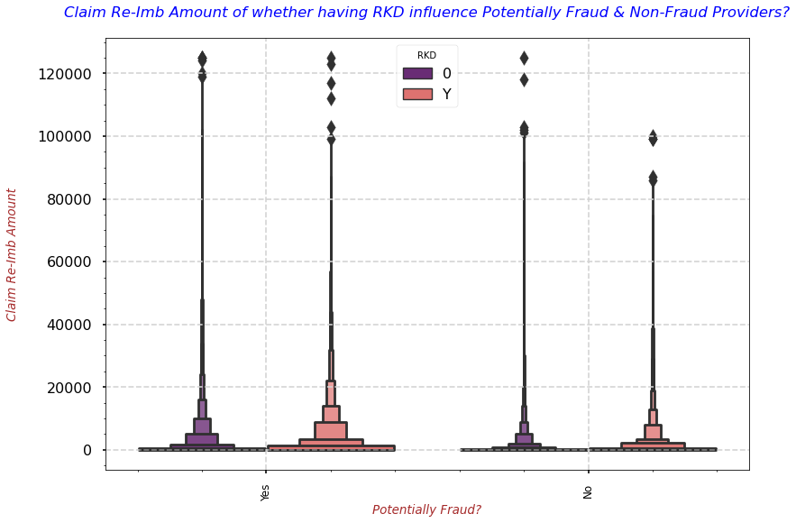

```python
with plt.style.context('seaborn-poster'):
    fig = sns.boxenplot(data=train_iobp_df, x='PotentialFraud',y='InscClaimAmtReimbursed', hue='RenalDiseaseIndicator',palette='magma')
    # Providing the labels and title to the graph
    plt.xlabel("Potentially Fraud?", fontdict=label_font_dict)
    plt.xticks(rotation=90, fontsize=12)
    plt.ylabel("Claim Re-Imb Amount\n", fontdict=label_font_dict)
    plt.minorticks_on()
    plt.grid(which='major', linestyle="--", color='lightgrey')
    plt.title("Claim Re-Imb Amount of whether having RKD influence Potentially Fraud & Non-Fraud Providers?\n", fontdict=title_font_dict)
    plt.legend(loc='upper center', title='RKD');
```

**`OBSERVATION`**

- The above plot clearly shows us that there is no difference in the distribution of Claim Re-Imb Amount of patients with or w/o RKD for Potentially Fraud and Non-Fraud Providers.
  - Therefore, we can say that claim Re-Imb Amount might not be useful in segregating the Fraud cases.

### **Does `IPAnnualReimbursementAmt` influences `Potentially Fraud`?**

- **Relationship b/w `IPAnnualReimbursementAmt` and `Potentially Fraud`**

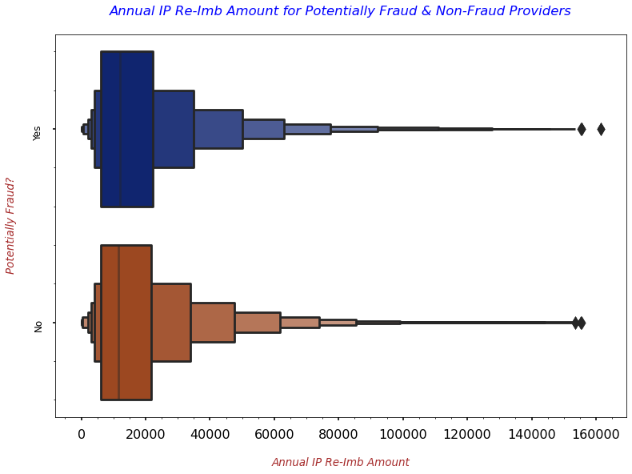

```python
with plt.style.context('seaborn-poster'):
    fig = sns.boxenplot(data=train_iobp_df[train_iobp_df['Admitted?'] == 1], y='PotentialFraud',x='IPAnnualReimbursementAmt',
                         palette='dark', orient='h')
    # Providing the labels and title to the graph
    plt.ylabel("Potentially Fraud?\n", fontdict=label_font_dict)
    plt.yticks(rotation=90, fontsize=12)
    plt.xlabel("\nAnnual IP Re-Imb Amount", fontdict=label_font_dict)
    plt.minorticks_on()
    plt.title("Annual IP Re-Imb Amount for Potentially Fraud & Non-Fraud Providers\n", fontdict=title_font_dict)
    plt.plot();
```

**`OBSERVATION`**

- The above plot clearly shows us that there is no difference in the distribution of Annual IP Re-Imb Amount for Potentially Fraud and Non-Fraud Providers.
  - And, it looks like a Pareto Distribution.

#### **Why do we have `IP Annual Re-Imb Amount` as `0` for `Admitted Patients`?**

```python
print(pd.DataFrame(train_iobp_df[(train_iobp_df['IPAnnualReimbursementAmt'] == 0)]['Admitted?'].value_counts()))
```

```
   Admitted?
0     371263
1        413
```

- So, we have 413 claims where Patients were admitted to the hospital but the allocated `IP Annual Re-Imb Amt` is 0.

```python
print(pd.DataFrame(train_iobp_df[(train_iobp_df['IPAnnualReimbursementAmt'] == 0) & (train_iobp_df['Admitted?'] == 1)]\
                   ['PotentialFraud'].value_counts()))
```

```
     PotentialFraud
Yes             249
No              164
```

- So, out 413 claims 60% of them means 249 are fraudulent whereas 164 are non-fraudulent.

**`OBSERVATION`**

- **Thus, we can say that if the IP Annual Amount is 0 and patient was admitted to the hospital then chances of being fraudulent are high.**
- **Relationship b/w `IPAnnualReimbursementAmt` and `Potentially Fraud` for both the `Genders`**

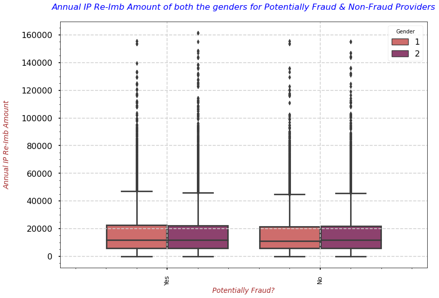

```python
with plt.style.context('seaborn-poster'):
    fig = sns.boxplot(data=train_iobp_df[train_iobp_df['Admitted?'] == 1], x='PotentialFraud',y='IPAnnualReimbursementAmt', hue='Gender',
                      palette='flare')
    # Providing the labels and title to the graph
    plt.xlabel("Potentially Fraud?", fontdict=label_font_dict)
    plt.xticks(rotation=90, fontsize=12)
    plt.ylabel("Annual IP Re-Imb Amount\n", fontdict=label_font_dict)
    plt.minorticks_on()
    plt.grid(which='major', linestyle="--", color='lightgrey')
    plt.title("Annual IP Re-Imb Amount of both the genders for Potentially Fraud & Non-Fraud Providers\n", fontdict=title_font_dict)
    plt.plot();
```

**`OBSERVATION`**

- The above plot clearly shows us that there is no difference in the distribution of Annual IP Re-Imb Amount of males and females for Potentially Fraud and Non-Fraud Providers.
  - Therefore, we can say that Annual IP Re-Imb Amount might not be useful in segregating the Fraud cases.
- **Relationship b/w `IPAnnualReimbursementAmt` and `Potentially Fraud` for `Is_Alive?`**

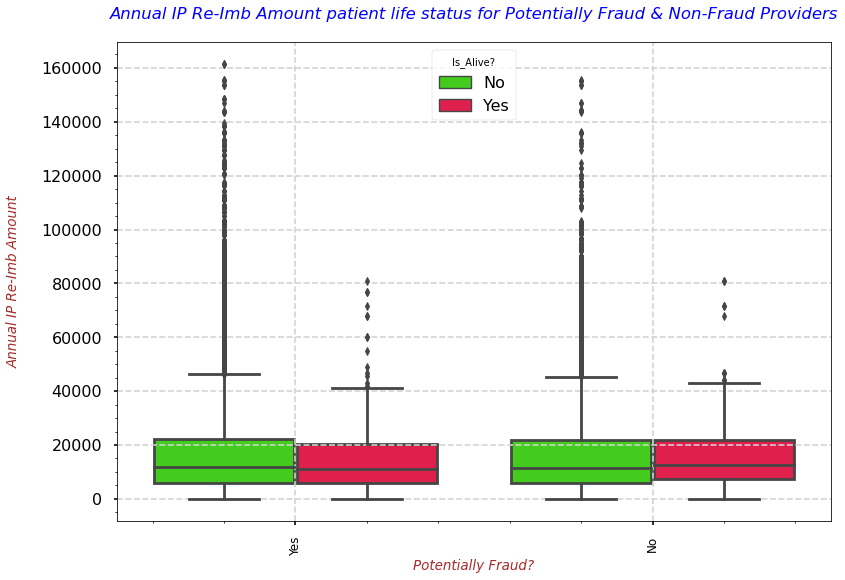

```python
with plt.style.context('seaborn-poster'):
    fig = sns.boxplot(data=train_iobp_df[train_iobp_df['Admitted?'] == 1], x='PotentialFraud',y='IPAnnualReimbursementAmt', hue='Is_Alive?',
                      palette='prism')
    # Providing the labels and title to the graph
    plt.xlabel("Potentially Fraud?", fontdict=label_font_dict)
    plt.xticks(rotation=90, fontsize=12)
    plt.ylabel("Annual IP Re-Imb Amount\n", fontdict=label_font_dict)
    plt.minorticks_on()
    plt.grid(which='major', linestyle="--", color='lightgrey')
    plt.title("Annual IP Re-Imb Amount patient life status for Potentially Fraud & Non-Fraud Providers\n", fontdict=title_font_dict)
    plt.legend(loc="upper center", title='Is_Alive?');
```

**`OBSERVATION`**

- The above plot clearly shows us that there is no difference in the distribution of Annual IP Re-Imb Amount on patient life status for Potentially Fraud and Non-Fraud Providers.
  - Therefore, we can say that Annual IP Re-Imb Amount might not be useful in segregating the Fraud cases.
- **Relationship b/w `IPAnnualReimbursementAmt` and `Potentially Fraud` for all `Human Races`**

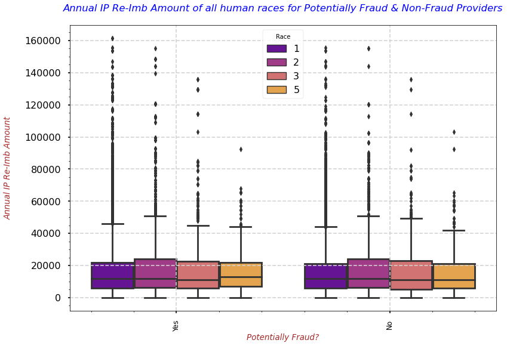

```python
with plt.style.context('seaborn-poster'):
    fig = sns.boxplot(data=train_iobp_df[train_iobp_df['Admitted?'] == 1], x='PotentialFraud',y='IPAnnualReimbursementAmt', hue='Race',
                      palette='plasma')
    # Providing the labels and title to the graph
    plt.xlabel("Potentially Fraud?", fontdict=label_font_dict)
    plt.xticks(rotation=90, fontsize=12)
    plt.ylabel("Annual IP Re-Imb Amount\n", fontdict=label_font_dict)
    plt.minorticks_on()
    plt.grid(which='major', linestyle="--", color='lightgrey')
    plt.title("Annual IP Re-Imb Amount of all human races for Potentially Fraud & Non-Fraud Providers\n", fontdict=title_font_dict)
    plt.legend(loc="upper center", title="Race");
```

**`OBSERVATION`**

- The above plot clearly shows us that there is no difference in the distribution of Annual IP Re-Imb Amount of all human races for Potentially Fraud and Non-Fraud Providers.
  - Therefore, we can say that Annual IP Re-Imb Amount might not be useful in segregating the Fraud cases.
- **Relationship b/w `IPAnnualReimbursementAmt` and `Potentially Fraud` for `RenalDiseaseIndicator`**

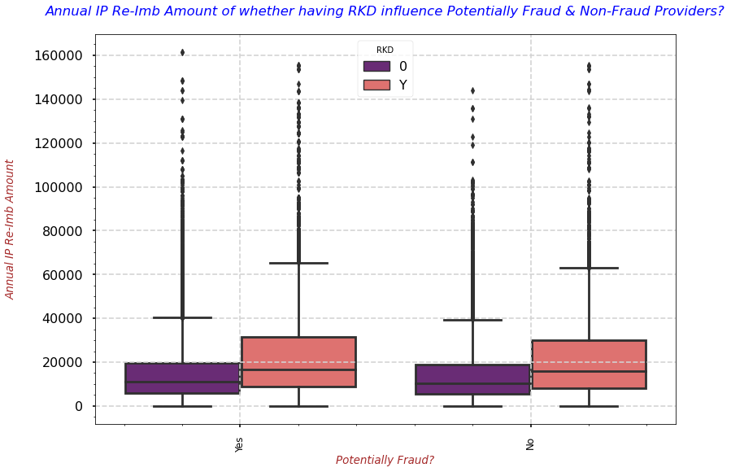

```python
with plt.style.context('seaborn-poster'):
    fig = sns.boxplot(data=train_iobp_df[train_iobp_df['Admitted?'] == 1], x='PotentialFraud',y='IPAnnualReimbursementAmt',
                      hue='RenalDiseaseIndicator',palette='magma')
    # Providing the labels and title to the graph
    plt.xlabel("Potentially Fraud?", fontdict=label_font_dict)
    plt.xticks(rotation=90, fontsize=12)
    plt.ylabel("Annual IP Re-Imb Amount\n", fontdict=label_font_dict)
    plt.minorticks_on()
    plt.grid(which='major', linestyle="--", color='lightgrey')
    plt.title("Annual IP Re-Imb Amount of whether having RKD influence Potentially Fraud & Non-Fraud Providers?\n", fontdict=title_font_dict)
    plt.legend(loc='upper center', title='RKD');
```

**`OBSERVATION`**

- The above plot clearly shows us that there is a very slight difference in the distribution of Annual IP Re-Imb Amount of patients with or w/o RKD for Potentially Fraud and Non-Fraud Providers.
  - Therefore, we can say that Annual IP Re-Imb Amount might not be useful in segregating the Fraud cases.

### **Does `OPAnnualReimbursementAmt` influences `Potentially Fraud`?**

- **Relationship b/w `OPAnnualReimbursementAmt` and `Potentially Fraud`**

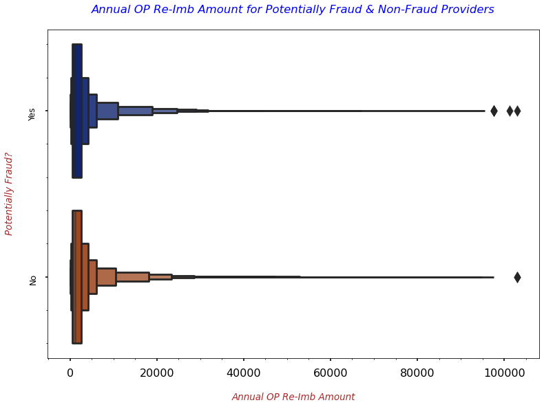

```python
with plt.style.context('seaborn-poster'):
    fig = sns.boxenplot(data=train_iobp_df[train_iobp_df['Admitted?'] == 0], y='PotentialFraud', x='OPAnnualReimbursementAmt',
                         palette='dark', orient='h')
    # Providing the labels and title to the graph
    plt.ylabel("Potentially Fraud?\n", fontdict=label_font_dict)
    plt.yticks(rotation=90, fontsize=12)
    plt.xlabel("\nAnnual OP Re-Imb Amount", fontdict=label_font_dict)
    plt.minorticks_on()
    plt.title("Annual OP Re-Imb Amount for Potentially Fraud & Non-Fraud Providers\n", fontdict=title_font_dict)
    plt.plot();
```

**`OBSERVATION`**

- The above plot clearly shows us that there is no difference in the distribution of Annual OP Re-Imb Amount for Potentially Fraud and Non-Fraud Providers.
  - And, it looks like a Pareto Distribution.

#### **Why do we have `OP Annual Re-Imb Amount` as `0` for `Admitted Patients`?**

```python
print(pd.DataFrame(train_iobp_df[(train_iobp_df['OPAnnualReimbursementAmt'] == 0)]['Admitted?'].value_counts()))
```

```
   Admitted?
1       3909
0       1009
```

- So, we have 1009 claims where Patients were not admitted to the hospital but the allocated `OP Annual Re-Imb Amt` is 0.

```python
print(pd.DataFrame(train_iobp_df[(train_iobp_df['OPAnnualReimbursementAmt'] == 0) & (train_iobp_df['Admitted?'] == 0)]\
                   ['PotentialFraud'].value_counts()))
```

```
     PotentialFraud
No              617
Yes             392
```

- So, out 1009 claims 38% of them means 392 are fraudulent whereas 62% or 617 are non-fraudulent.

**`OBSERVATION`**

- **Thus, we can say that if the OP Annual Amount is 0 and patient was not admitted to the hospital then chances of being fraudulent are less.**
- **Relationship b/w `OPAnnualReimbursementAmt` and `Potentially Fraud` for both the `Genders`**

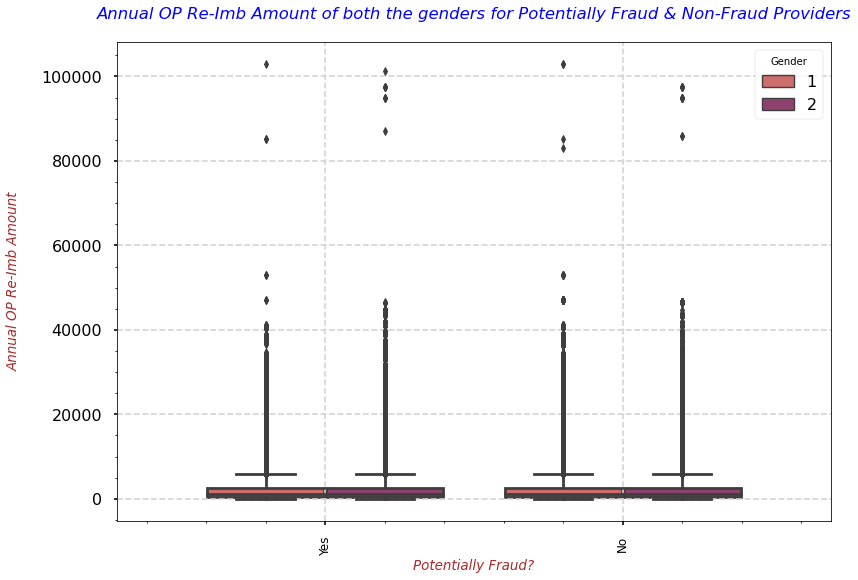

```python
with plt.style.context('seaborn-poster'):
    fig = sns.boxplot(data=train_iobp_df[train_iobp_df['Admitted?'] == 0], x='PotentialFraud',y='OPAnnualReimbursementAmt', hue='Gender',
                      palette='flare')
    # Providing the labels and title to the graph
    plt.xlabel("Potentially Fraud?", fontdict=label_font_dict)
    plt.xticks(rotation=90, fontsize=12)
    plt.ylabel("Annual OP Re-Imb Amount\n", fontdict=label_font_dict)
    plt.minorticks_on()
    plt.grid(which='major', linestyle="--", color='lightgrey')
    plt.title("Annual OP Re-Imb Amount of both the genders for Potentially Fraud & Non-Fraud Providers\n", fontdict=title_font_dict)
    plt.plot();
```

**`OBSERVATION`**

- The above plot clearly shows us that there is no difference in the distribution of Annual OP Re-Imb Amount of males and females for Potentially Fraud and Non-Fraud Providers.
  - Therefore, we can say that Annual OP Re-Imb Amount might not be useful in segregating the Fraud cases.
- **Relationship b/w `OPAnnualReimbursementAmt` and `Potentially Fraud` for `Is_Alive?`**

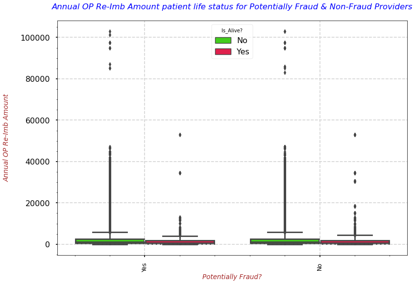

```python
with plt.style.context('seaborn-poster'):
    fig = sns.boxplot(data=train_iobp_df[train_iobp_df['Admitted?'] == 0], x='PotentialFraud',y='OPAnnualReimbursementAmt', hue='Is_Alive?',
                      palette='prism')
    # Providing the labels and title to the graph
    plt.xlabel("Potentially Fraud?", fontdict=label_font_dict)
    plt.xticks(rotation=90, fontsize=12)
    plt.ylabel("Annual OP Re-Imb Amount\n", fontdict=label_font_dict)
    plt.minorticks_on()
    plt.grid(which='major', linestyle="--", color='lightgrey')
    plt.title("Annual OP Re-Imb Amount patient life status for Potentially Fraud & Non-Fraud Providers\n", fontdict=title_font_dict)
    plt.legend(loc="upper center", title='Is_Alive?');
```

**`OBSERVATION`**

- The above plot clearly shows us that there is no difference in the distribution of Annual OP Re-Imb Amount on patient life status for Potentially Fraud and Non-Fraud Providers.
  - Therefore, we can say that Annual OP Re-Imb Amount might not be useful in segregating the Fraud cases.
- **Relationship b/w `OPAnnualReimbursementAmt` and `Potentially Fraud` for all `Human Races`**

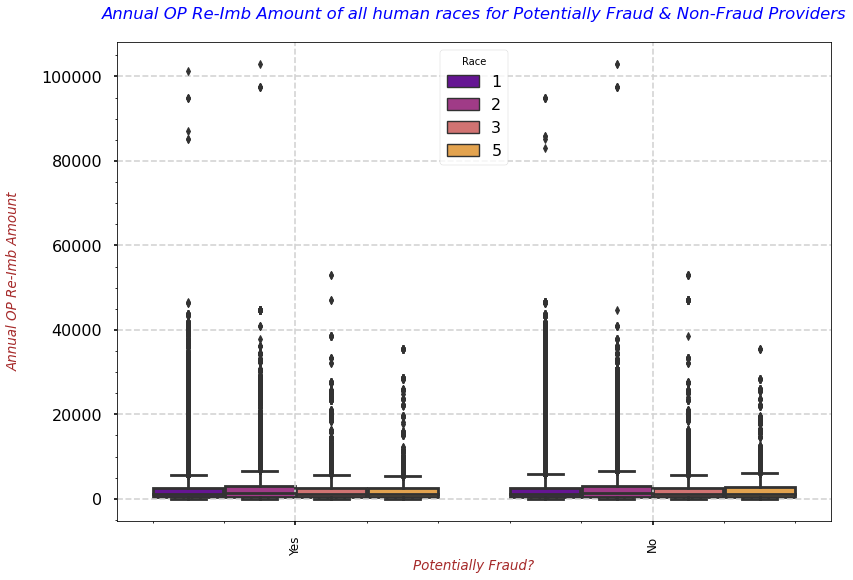

```python
with plt.style.context('seaborn-poster'):
    fig = sns.boxplot(data=train_iobp_df[train_iobp_df['Admitted?'] == 0], x='PotentialFraud',y='OPAnnualReimbursementAmt', hue='Race',
                      palette='plasma')
    # Providing the labels and title to the graph
    plt.xlabel("Potentially Fraud?", fontdict=label_font_dict)
    plt.xticks(rotation=90, fontsize=12)
    plt.ylabel("Annual OP Re-Imb Amount\n", fontdict=label_font_dict)
    plt.minorticks_on()
    plt.grid(which='major', linestyle="--", color='lightgrey')
    plt.title("Annual OP Re-Imb Amount of all human races for Potentially Fraud & Non-Fraud Providers\n", fontdict=title_font_dict)
    plt.legend(loc="upper center", title="Race");
```

**`OBSERVATION`**

- The above plot clearly shows us that there is no difference in the distribution of Annual OP Re-Imb Amount of all human races for Potentially Fraud and Non-Fraud Providers.
  - Therefore, we can say that Annual OP Re-Imb Amount might not be useful in segregating the Fraud cases.
- **Relationship b/w `OPAnnualReimbursementAmt` and `Potentially Fraud` for `RenalDiseaseIndicator`**

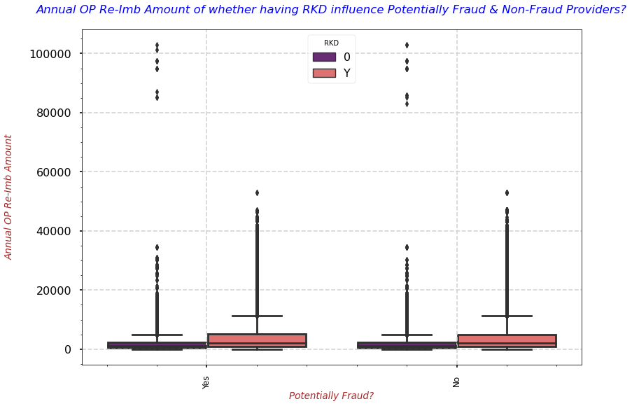

```python
with plt.style.context('seaborn-poster'):
    fig = sns.boxplot(data=train_iobp_df[train_iobp_df['Admitted?'] == 0], x='PotentialFraud',y='OPAnnualReimbursementAmt',
                      hue='RenalDiseaseIndicator',palette='magma')
    # Providing the labels and title to the graph
    plt.xlabel("Potentially Fraud?", fontdict=label_font_dict)
    plt.xticks(rotation=90, fontsize=12)
    plt.ylabel("Annual OP Re-Imb Amount\n", fontdict=label_font_dict)
    plt.minorticks_on()
    plt.grid(which='major', linestyle="--", color='lightgrey')
    plt.title("Annual OP Re-Imb Amount of whether having RKD influence Potentially Fraud & Non-Fraud Providers?\n", fontdict=title_font_dict)
    plt.legend(loc='upper center', title='RKD');
```

**`OBSERVATION`**

- The above plot clearly shows us that there is a very slight difference in the distribution of Annual OP Re-Imb Amount of patients with or w/o RKD for Potentially Fraud and Non-Fraud Providers.
  - Therefore, we can say that Annual OP Re-Imb Amount might not be useful in segregating the Fraud cases.